# Lecture 22: Differential abundance analysis of Microbiome data

28/09/2024

# Microbiome Differential Abundance Analysis With DESeq2 - A basic workflow

**References**

[DESeq2 workflow tutorial | Differential Gene Expression Analysis | Bioinformatics 101](https://youtu.be/OzNzO8qwwp0?si=d-aEqtqNo8YWTYW6)

**Additional references for DESeq2**

[Bulk RNA-seq 8: Downstream analysis of Bulk RNA-seq (start from 1:15:10)](https://youtu.be/N8AruRYfigA?si=dnLLgqT0UhXvovi-)

[How Does DESeq2 Work? | Mr. BioinformatiX on Youtube](https://youtu.be/Mhw5a-anLJ4?si=cBKMa_A2-1Tul96M)

[“Analyzing RNA-seq data with DESeq2” from bioconductor](https://bioconductor.org/packages/devel/bioc/vignettes/DESeq2/inst/doc/DESeq2.html)

[Example using Negative Binomial in Microbiome Differential Abundance Testing](https://bioconductor.org/packages/devel/bioc/vignettes/phyloseq/inst/doc/phyloseq-mixture-models.html)

[How I analyze RNA Seq Gene Expression data using DESeq2](https://www.youtube.com/watch?v=kOlMcZujHHA&list=PL5T9th5waOqzb4bO6ZvG66sKDO6W-ssQr&index=25)

[DESeq2’s manual from Michael Love](https://bioconductor.org/packages/release/bioc/manuals/DESeq2/man/DESeq2.pdf)

[DESeq2’s Paper: Moderated estimation of fold change and dispersion for RNA-seq data with DESeq2](https://genomebiology.biomedcentral.com/articles/10.1186/s13059-014-0550-8)

## Install packages

```r
#Install DESeq2
if (!require("BiocManager", quietly = TRUE))
    install.packages("BiocManager")

BiocManager::install("DESeq2")

install.packages("ggplot2") #Install ggplot2

BiocManager::install("EnhancedVolcano") #Install EnhancedVolcano
```

## Load packages

```r
library(DESeq2)
library(EnhancedVolcano)
```

```r
library(ggplot2)
```

## the simulation dataset

Here, I use the simulation dataset to run with DESeq2.

Includes 2 files:

1. “otu_data” file is the raw count table file: There are 91 otu (rows) and 150 samples (columns).
2. “smd” file is the metadata file: there are 150 samples (rows) corresponding to 150 samples (columns) of the otu_data file; and 3 columns, in this case we look at the 3rd column named “health_status”

### Prepare count data

**Read in counts data:**

```r
#Load a .RData file named "otu_data"
#The object will be loaded into the environment with its original name
load("C:/Users/KhaiNguyen/OneDrive/Documents/deseq2_practice/otu_data")

#Create a object named "counts.data"
counts.data <- otu_data

#Check
ncol(counts.data)
```

```
## [1] 150
```

```r
head(counts.data)
```

```
##     S1 S2  S3  S4  S5 S6 S7 S8 S9 S10 S11 S12 S13 S14 S15 S16 S17 S18 S19 S20
## T1   1  0   1   3   2  0  1  0  0   3   0   3   2   3   0   0   0   5   0   2
## T2 102  1 156 535 178  0 99 21 28 400  60 486 357 397  23  14  57 571   3 716
## T3   0  0   0   0   0  0  0  0  0   0   0   0   0   0   0   0   0   1   0   0
## T4   4  0   7  23  11  0  6  1  1  19   2  23  13  20   1   1   2  33   0  17
## T5  38  0  65 214  90  0 52  7  9 173  23 211 125 177   9   6  21 281   1 189
## T6  15  0  26  85  38  0 23  3  3  70   9  86  47  73   3   2   8 120   0  65
##    S21 S22 S23 S24  S25 S26 S27 S28 S29 S30 S31 S32 S33 S34 S35 S36 S37 S38 S39
## T1   0   1   1   1    3   1   0   2   0   3   4   3   0   0   2   2   0   0   1
## T2  35 127 108 232 1037 121  51 315  18 822 699 771  52  81 287 409  60  38 231
## T3   0   0   0   0    0   0   0   0   0   0   0   0   0   0   0   0   0   0   0
## T4   1   8   4   8   24   6   2  13   1  25  29  22   3   2  11  15   2   1   8
## T5  14  68  41  78  267  56  21 121   8 257 275 232  25  20 107 146  18  13  77
## T6   5  30  16  29   91  24   8  47   3  93 108  83  10   7  41  55   7   5  29
##    S40 S41 S42 S43 S44 S45 S46 S47 S48 S49  S50 S51 S52  S53  S54 S55  S56 S57
## T1   3   0   0   0   0   2   0   2   2   3    4   2   4   32   32  15   25   0
## T2 786 100   2  48  34 406  34 374 574 610 1355  71  86 1886  837 299  531   6
## T3   0   0   0   0   0   0   0   0   0   0    0   0   0    3    3   2    3   0
## T4  22   2   0   1   1  15   1  15  16  23   31  17  27  254  224 101  168   2
## T5 236  26   1  13  12 147  10 145 166 225  354 173 258 3079 2203 926 1567  18
## T6  85   9   0   4   5  56   4  57  58  87  120  64 102  986  841 371  622   8
##    S58 S59 S60  S61 S62 S63 S64 S65 S66 S67 S68 S69  S70  S71 S72 S73 S74 S75
## T1   0   3  13   78   3   1   1   3   2   0   8   6   80   72   0   1   2  11
## T2   3  82 407 2088  50  15  50  60  27   0 234 141 2266 1739   9  15  71 204
## T3   0   0   1    8   0   0   0   0   0   0   1   1    8    8   0   0   0   1
## T4   1  22  93  553  19   4  10  19  11   0  57  39  572  503   3   5  17  76
## T5   7 217 955 5446 169  38 107 173  92   1 575 374 5723 4814  31  44 173 670
## T6   2  82 350 2071  69  14  37  68  38   0 213 145 2139 1861  13  17  64 275
##     S76  S77  S78 S79  S80  S81 S82 S83 S84 S85  S86 S87 S88 S89 S90  S91 S92
## T1   15   37   50   8   16   22   7  13   8   2   29   1   5   0   1   51   8
## T2  413 1062 1280 179  375  803 177 303 205  37  695  37 267   5  26 1213 256
## T3    2    4    5   1    2    2   1   1   1   0    3   0   0   0   0    5   1
## T4  108  263  355  54  111  163  53  91  57  13  201   7  39   3  10  360  61
## T5 1077 2640 3441 507 1055 1744 499 861 550 117 1935  76 457  22  87 3421 619
## T6  408  982 1320 200  412  617 194 335 211  47  750  26 151  10  36 1323 229
##    S93 S94 S95  S96 S97  S98 S99 S100  S101   S102   S103 S104   S105  S106
## T1   0   0   0   29   4   22   0    1    80    627    693    1    508    60
## T2   9   1   1  787  76  783   0   11 29731 268594 663078  615 347404 31480
## T3   0   0   0    3   0    2   0    0     8     64     65    0     51     7
## T4   2   0   0  204  26  161   0    4   551   4272   5329    8   3696   421
```

[output cut: 15 more lines]

```
## T6  370   473  1596  163   4274   59  19209  5114  248  4597   876  154  188
##      S134 S135  S136  S137  S138 S139  S140  S141 S142  S143   S144  S145  S146
## T1    422   11   294   149    98    1   120   142    2   208    232   105    64
## T2 259486 5882 78315 79312 43795  950 52238 41555  940 69158 150981 68451 40298
## T3     43    1    31    14    11    0    13    17    0    22     23    10     7
## T4   3047   82  1886  1050   694   10   805   913   12  1364   1673   767   465
## T5  31019  772 15409 10384  6383  101  7580  7678  118 11913  17441  7893  4766
## T6  11432  292  6736  3934  2532   36  2985  3302   45  4985   6334  2864  1756
##      S147  S148  S149 S150
## T1    317    41   320   14
## T2 258659 23841 79188 7491
## T3     32     4    35    2
## T4   2340   293  2036   96
## T5  26071  2888 16343  975
## T6   8992  1100  7295  364
```

**Read in sample info:**

```r
#Load a .RData file named "smd"
#The object will be loaded into the environment with its original name
load("C:/Users/KhaiNguyen/OneDrive/Documents/deseq2_practice/smd")

#Create a object named "meta.data"
meta.data <- smd

#Check
nrow(meta.data)
```

```
## [1] 150
```

```r
head(meta.data)
```

```
##    stand_bmi stand_choles health_status
## S1 -7.046117  -0.05133271             1
## S2 -8.183509  -1.30178093             1
## S3 -7.369319  -1.20561056             1
## S4 -7.796003   0.11530542             1
## S5 -7.403773   0.78781710             1
## S6 -8.488528  -0.64191981             1
```

**Check a little bit:**

```r
#Making sure the row names in meta.data matches to column names in counts.data**
all(colnames(counts.data) %in% rownames(meta.data))
```

```
## [1] TRUE
```

```r
#Are they in the same order?
all(colnames(counts.data) == rownames(meta.data))
```

```
## [1] TRUE
```

### Construct a DESeqDataSet object

```r
# Construct a DESeqDataSet object with DESeqDataSetFromMatrix() function in DESeq2
dds <- DESeqDataSetFromMatrix(countData = counts.data,
                              colData = meta.data,
                              design = ~ health_status)
dds #Show results
```

```
## class: DESeqDataSet
## dim: 91 150
## metadata(1): version
## assays(1): counts
## rownames(91): T1 T2 ... T90 T91
## rowData names(0):
## colnames(150): S1 S2 ... S149 S150
## colData names(3): stand_bmi stand_choles health_status
```

**[OPTION] pre-filtering: removing OTU with low read counts**

When analyzing differential abundance in microbial studies, a common practice is to use OTUs that have a certain minimum number of reads across all samples to ensure that the analysis is statistically robust and to avoid noise from low-abundance OTUs.

*Common Thresholds*

- Minimum Reads per OTU: Typically, researchers require that an OTU have at least 10 to 100 reads across all samples to be included in the analysis. The exact threshold can vary based on the study design, sample size, sequencing depth, and the research question.
- Prevalence Filtering: Some studies also require that an OTU must be present in a certain percentage of samples (e.g., at least 10% of the samples) to be considered for analysis.

*References*

Callahan, B. J., McMurdie, P. J., Rosen, M. J., Han, A. W., Johnson, A. J., & Holmes, S. P. (2016). DADA2: High-resolution sample inference from Illumina amplicon data. Nature Methods, 13(7), 581-583.  
–> In this study, they recommend filtering OTUs with low abundance to reduce noise in the data.

Weiss, S., Xu, Z. Z., Peddada, S., Amir, A., Bittinger, K., Gonzalez, A., … & Knight, R. (2017). Normalization and microbial differential abundance strategies depend upon data characteristics. Microbiome, 5(1), 27.  
–> This study evaluates the impact of different preprocessing strategies, including minimum read thresholds for OTUs.

```r
# keeping OTU that have at least 10 reads total
keep <- rowSums(counts(dds)) >= 10
dds <- dds[keep,]

dds
```

```
## class: DESeqDataSet
## dim: 91 150
## metadata(1): version
## assays(1): counts
## rownames(91): T1 T2 ... T90 T91
## rowData names(0):
## colnames(150): S1 S2 ... S149 S150
## colData names(3): stand_bmi stand_choles health_status
```

**Run DESeq2**

*Note:* If *results()* is run without specifying contrast or name, it will return the comparison of **the last level** of the last variable in the design formula over **the first level** of this variable. In this case: **the last level** is “3”, **the first level** is “1”

```r
# Run DESeq2
dds <- DESeq(dds)
#Set threshold for adjusted P value < 0.05, and |log2FoldChange| > 1
res <- results(dds, alpha = 0.05, lfcThreshold = 1)
res
```

```
## log2 fold change (MLE): health status 3 vs 1
## Wald test p-value: health status 3 vs 1
## DataFrame with 91 rows and 6 columns
##        baseMean log2FoldChange     lfcSE      stat      pvalue        padj
##       <numeric>      <numeric> <numeric> <numeric>   <numeric>   <numeric>
## T1     3.937139      0.1483879  0.240957  0.615828 9.99797e-01 1.00000e+00
## T2  1011.904104      1.4748846  0.086619 17.027274 2.09730e-08 9.54272e-07
## T3     0.235839     -1.4079341  0.371603 -3.788808 1.36153e-01 1.00000e+00
## T4    31.459318      0.1157326  0.174191  0.664400 1.00000e+00 1.00000e+00
## T5   309.370029      0.0513262  0.141044  0.363903 1.00000e+00 1.00000e+00
## ...         ...            ...       ...       ...         ...         ...
## T87  2841.84337      1.0270107  0.335661  3.059670    0.467932           1
## T88    22.87318      0.0878157  0.168082  0.522457    1.000000           1
## T89     4.26348      0.1329181  0.235064  0.565455    0.999888           1
## T90   114.33017      0.0856180  0.135888  0.630062    1.000000           1
## T91    86.16669     -0.4780970  0.312337 -1.530711    0.952637           1
```

```r
#Compare 2 to 3
res2_3 <- results(dds, contrast = c("health_status", "2", "3"))

res2_3
```

```
## log2 fold change (MLE): health_status 2 vs 3
## Wald test p-value: health_status 2 vs 3
## DataFrame with 91 rows and 6 columns
##        baseMean log2FoldChange     lfcSE       stat     pvalue      padj
##       <numeric>      <numeric> <numeric>  <numeric>  <numeric> <numeric>
## T1     3.937139     -0.2897670 0.1945421  -1.489482   0.136360  0.489392
## T2  1011.904104     -4.4063769 0.0885532 -49.759658   0.000000  0.000000
## T3     0.235839      0.1778922 0.3339510   0.532689   0.594249  0.691568
## T4    31.459318     -0.1950675 0.1591004  -1.226066   0.220174  0.513270
## T5   309.370029     -0.0751872 0.1378766  -0.545323   0.585532  0.691568
## ...         ...            ...       ...        ...        ...       ...
## T87  2841.84337      -0.994625  0.334335  -2.974933 0.00293053 0.0222232
## T88    22.87318      -0.197354  0.148942  -1.325041 0.18515763 0.4893922
## T89     4.26348      -0.240074  0.189151  -1.269223 0.20436159 0.4893922
## T90   114.33017      -0.104206  0.129241  -0.806296 0.42007214 0.5791904
## T91    86.16669       0.529379  0.307640   1.720775 0.08529167 0.4893922
```

### Explore Results

```r
summary(res)
```

```
##
## out of 91 with nonzero total read count
## adjusted p-value < 0.05
## LFC > 1.00 (up)    : 6, 6.6%
## LFC < -1.00 (down) : 0, 0%
## outliers [1]       : 0, 0%
## low counts [2]     : 0, 0%
## (mean count < 0)
## [1] see 'cooksCutoff' argument of ?results
## [2] see 'independentFiltering' argument of ?results
```

With adjusted P-value < 0.05 and |log2FoldChange| > 1, we have total 6 features

### Visualization

MA plot by plotMA() function in DESeq2:

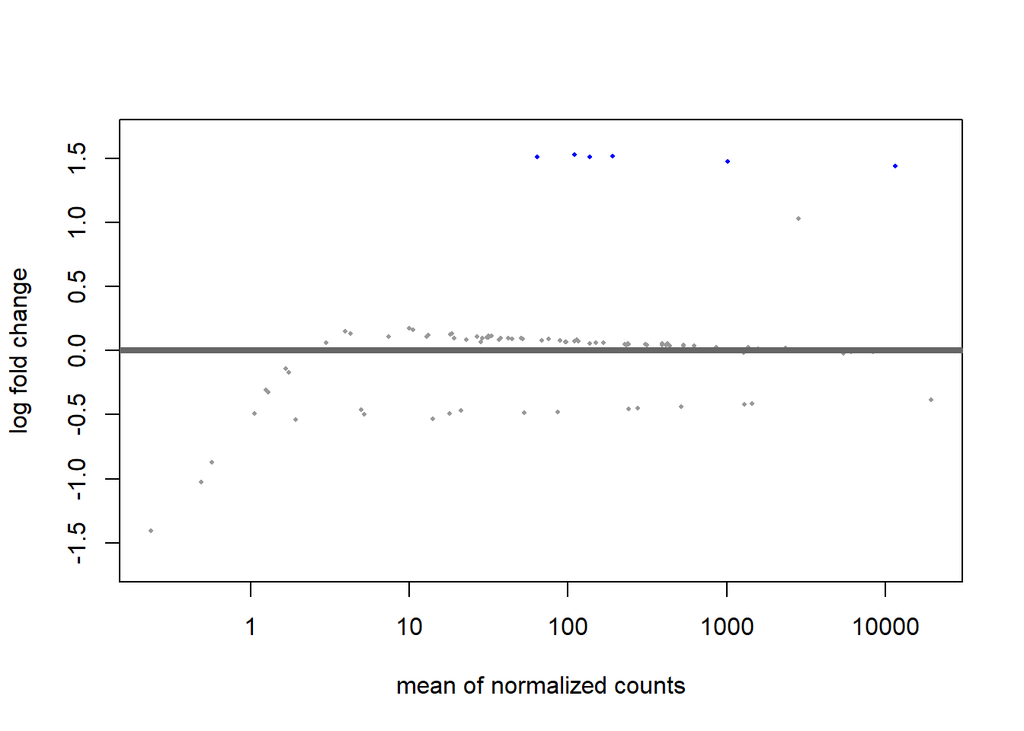

```r
plotMA(res)
```

**Volcano plot**

Volcano plot using EnhancedValcano pakages:

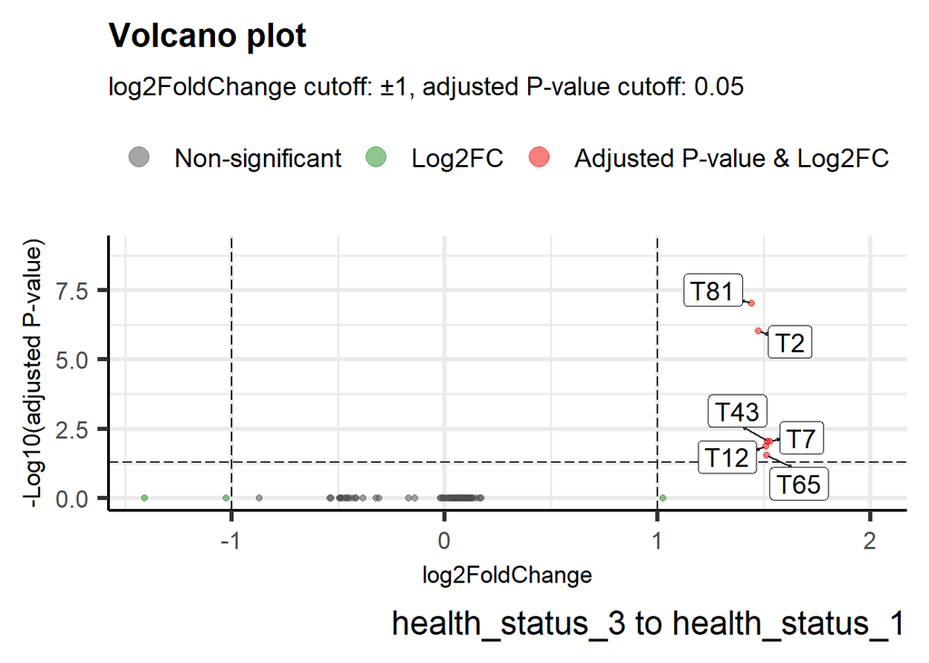

```r
# Create EnhancedVolcano plot
EnhancedVolcano(res,
                lab = rownames(res),
                title = 'Volcano plot',            # Title of the plot
                subtitle = 'log2FoldChange cutoff: ±1, adjusted P-value cutoff: 0.05', # Subtitle of the plot
                x = 'log2FoldChange',
                y = 'padj',
                xlim = c(min(res$log2FoldChange), 2),
                ylim = c(0, -log10(10e-10)),
                xlab = 'log2FoldChange',
                ylab= '-Log10(adjusted P-value)',
                axisLabSize = 13,
                pCutoff = 0.05,
                FCcutoff = 1.0,
                pointSize = 1.5,
                legendLabels = c('Non-significant', 'Log2FC', 'Adjusted P-value', 'Adjusted P-value & Log2FC'),
                caption = 'health_status_3 to health_status_1',
                captionLabSize = 18,
                legendPosition = 'top', # Position of the legend  # Only label the selected points
                boxedLabels = TRUE,
                drawConnectors = TRUE)  # Optional: Connect labels with lines
```

In compare heal_status_3 to health_status_1. We have 6 features labeled on the valcano plot, which meet the requirements of adjusted P-value < 0.05 and |log2FoldChange| > 1

### Manual test

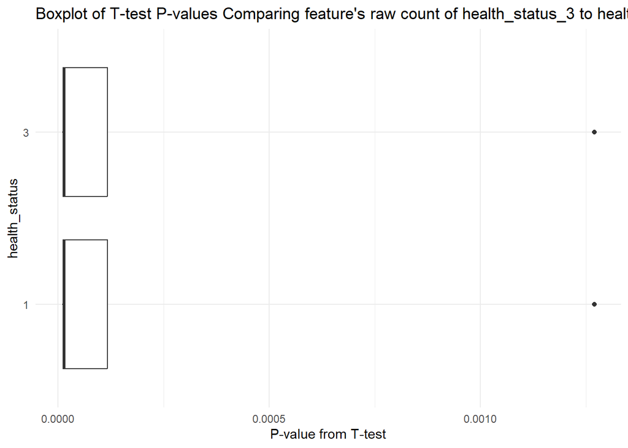

```r
#'dds' is your DESeqDataSet and 'res' is the DESeq2 results object

# Convert DESeq2 results to a data frame
res_df <- as.data.frame(res)

# Filter results based on padj < 0.05 and log2FoldChange > 1
filtered_res <- res_df[res_df$padj < 0.05 & abs(res_df$log2FoldChange) > 1, ]

# Extract raw counts
count_data <- counts(dds)

# Extract condition information
colData_dds <- colData(dds)
condition1_samples <- colData_dds$health_status == "1"
condition3_samples <- colData_dds$health_status == "3"

# Prepare a data frame to store p-values and group labels
plot_data <- data.frame()

# Perform t-test for each gene and collect p-values
for (gene in rownames(filtered_res)) {
  if (gene %in% rownames(count_data)) {
    counts_gene <- count_data[gene, ]
    t_test <- t.test(counts_gene[condition3_samples], counts_gene[condition1_samples])

    # Append results to plot_data
    plot_data <- rbind(plot_data, data.frame(
      Gene = gene,
      PValue = t_test$p.value,
      Group = rep(c("3", "1"), each = length(c(condition3_samples, condition1_samples)))
    ))
  }
}

# Create the boxplot
ggplot(plot_data, aes(x = PValue, y = Group)) +
  geom_boxplot() +
  labs(x = "P-value from T-test", y = "health_status", title = "Boxplot of T-test P-values Comparing feature's raw count of health_status_3 to health_status_1's") +
  scale_x_continuous(labels = scales::comma_format()) +
  theme_minimal()
```

Perform t-test compare raw count of features (with adjusted P-value < 0.05 and |log2FoldChange| > 1 in DESeq2) in health_status_3 with health_status_1: